# Brier_or_Bayes

```python
import matplotlib.pyplot as plt
import numpy as np
from scipy import stats
import scipy as sp
import seaborn as sns

import pymc3 as pm
```

```python
plt.style.use('seaborn')
%matplotlib inline
```

```python
from IPython.display import HTML
```

```python
HTML(
'''
<style>
.output_png {
    display: table-cell;
    text-align: center;
    vertical-align: middle;
}
</style>
<script>
code_show=true;
function code_toggle() {
 if (code_show){
 $('div.input').hide();
 } else {
 $('div.input').show();
 }
 code_show = !code_show
}
$( document ).ready(code_toggle);
</script>
The raw code for this IPython notebook is by default hidden for easier reading.
To toggle on/off the raw code, click <a href="javascript:code_toggle()">here</a>.
''')
```

The raw code for this IPython notebook is by default hidden for easier reading. To toggle on/off the raw code, click here.

# Brier or Bayes?

How institutions take decisions is one of the determining factors in how our future will look like. It is therefore crucial that institutions take *optimal* decisions. If our knowledge was complete-every aspect of the phenomenon that we are taking decisions about known-then decision-making would be just a matter of evaluating the relative utility of each choice. However, in reality we have to take decisions with limited information available. In order to take decisions with only partial knowledge, we are forced to *forecasting* what is going to happen.

Ultimately, forecasting is done by individuals, and different individuals are going to be more or less skilled at it. This raises the question: how do we assess whether an individual is a good forecaster? Various measures have been proposed. This brings us to the point of this blog: comparing different ways of measuring an individual's ability as a forecaster. We will be comparing two ways: the commonly used Brier score, and a Bayesian approach. I will first present a model of what forecasting, then explain the Brier score, then move to the Bayesian approach, and finally compare the two.

## A simple model of forecasting

Imagine that you are asked a series of questions about the probability of future events: "What is the probability that Trump will win the next election?", "What is the probability that most of your friends in 10 years will have dark hair?", etc. We write down your estimated probabilities and wait to see which of these events actually ends up happening. The idea is that each of these events will happen with a certain probability, and the better your estimate of the probabilities of these events happening, the better your forecasts will be.

We can represent you, the forecaster, as a noisy estimator of the probabilities of the events that you are asked about. Let's say that you are a perfect estimator: you always say the true probability of the event. Then, you will look like this:

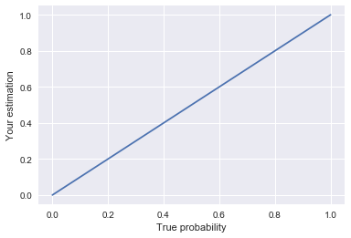

```python
xs = np.linspace(0,1,100)
ys = xs
plt.plot(xs, ys)
plt.xlabel("True probability")
plt.ylabel("Your estimation")
plt.show()
```

That is the optimal case: you always guess the right probability, always spot-on. If the true probability if 0.4, you answer 0.4 in the story above.

However, things are usually not this simple. Usually, people guess a probability that is *somewhere around* the true probability, rather than the exact true probability. So, if the true probability is e.g. 0.3, you might sometimes answer 0.1, and sometimes 0.4. If you are unbiased in your estimation of the true probability, over many questions you will be right on average, i.e. for a given true probability, the mean of your estimations will be close to that true probability. Something like the following:

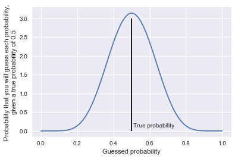

```python
ys = stats.beta.pdf(xs, 8,8)
plt.plot(xs, ys)
plt.vlines(0.5, 0.,3.)
plt.text(0.51, 0.1, "True probability")
plt.ylabel("Probability that you will guess each probability,\ngiven a true probability of 0.5")
plt.xlabel("Guessed probability")
plt.show()
```

If you are noisy for all true probabilities, your forecasting behaviour can be visualized as follows:

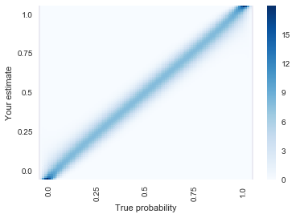

```python
def get_params(mu, sigma):
    alpha = mu**2 * ((1 - mu) / sigma**2 - 1 / mu)
    beta = alpha * (1 / mu - 1)
    return alpha, beta

fig, ax = plt.subplots()
xs_square, ys_square = np.mgrid[0.01:0.99:100j, 0.01:0.99:100j]
# ys_square
alphas, betas = get_params(mu=np.linspace(0.001, 0.999, 100), sigma=0.05)
values = stats.beta.pdf(x=xs_square, a=alphas, b=betas)
sns.heatmap(np.flipud(values), ax=ax, cmap="Blues")

ax.set_xticks(np.linspace(5, 95, 5))
ax.set_xticklabels(np.linspace(0,1, 5))
ax.set_yticks(np.linspace(95, 5, 5))
ax.set_yticklabels(np.linspace(0,1, 5))

ax.set_xlabel("True probability")
ax.set_ylabel("Your estimate")
plt.show()
```

For each true probability, there is a whole distribution over guesses you might take.

However, it is also possible that you have a bias, i.e. the mean of your guesses given the true probability is not identical to the true probability. So, even if you are perfectly confident and reliable in your answer-prompted about any even with a certain true probability, you will always give the same, wrong answer-you might be consistently inaccurate:

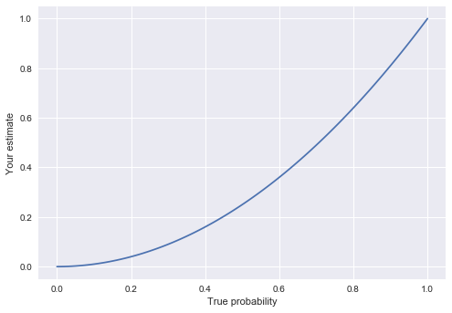

```python
ys = xs ** 2
plt.plot(xs, ys)
plt.xlabel("True probability")
plt.ylabel("Your estimate")
plt.show()
```

There are different ways of having a bias. For instance, you might consistently guess probabilities that are closer to an extreme than the real probabilities, which can be thought of as an overconfidence bias:

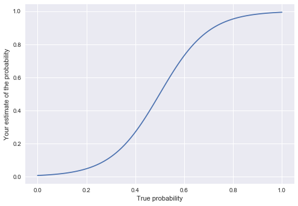

```python
def logistic_sigmoid(xs, L, x_0, k):
    return L / (1 + np.exp(-k*(xs-x_0)))

plt.plot(xs, logistic_sigmoid(xs, 1, 0.5, 10))
plt.xlabel("True probability")
plt.ylabel("Your estimate of the probability")
plt.show()
```

Or, on the other hand, you might consistently guess probability which are closer to 0.5 than the true probability. In that case, you'd be *underconfident*:

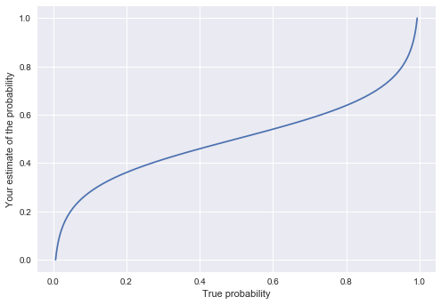

```python
plt.plot(logistic_sigmoid(xs, 1, 0.5, 10), xs)
plt.xlabel("True probability")
plt.ylabel("Your estimate of the probability")
plt.show()
```

And of course, on top of all these possible shapes your biases can take, there's still the issue of the fact that your estimations are going to differ for different events, even when those events have the same underlying probabilities. This can combine with the bias:

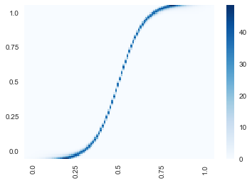

```python
mus = logistic_sigmoid(xs, 1, 0.5, 15)
alphas, betas = get_params(mus, 0.01)
fig, ax = plt.subplots()
sns.heatmap(np.flipud(stats.beta.pdf(x=xs_square, a=alphas, b=betas)), ax=ax, cmap="Blues")
ax.set_xticks(np.linspace(5, 95, 5))
ax.set_xticklabels(np.linspace(0,1, 5))
ax.set_yticks(np.linspace(95, 5, 5))
ax.set_yticklabels(np.linspace(0,1, 5))
plt.show()
```

Now that we have considered various possible ways that a forecaster might behave compared to the underlying true probabilities, you might be wondering: "but doesn't the relation between the forecaster and their estimation depend on very many things, e.g. what they know about the specific topic that they are asked about? And if so, how can we assume any stable relation at all between the true probabilities and their estimations?". That is true, but might not be as important as it first appears. Indeed, many factors go into a forecast, and only some of them depend on the ability of the forecaster. However, in many contexts we can assume a population of forecasters that all have the same available information, and moreover that that information is substantial enough to offer some guide as to what the true probabilities are. When comparing forecasters, we are interested in rating their *relative* forecasting accuracies. In such contexts, the factors beyond the skills as forecasters wash out. The crucial point to understand here is that, *even given similar information, not everybody is equally as skillful as a forecaster*, i.e. in producting probability estimations for future events when prompted. For instance, some people overestimate their confidence in a conclusion given the data, and others underestimate it.

To sum up, while above we have focused on the relation between true probability and its estimation by a forecaster, in reality there is an additional level between them, namely the data about the event that is available to the forecaster. The middle layer would be very hard to formalize, as it would have to consider many facts about the forecaster: exactly what they know about the event, as well as similar past events. However, when the middle layer is stable across forecasters in a population, the relation between the first and third layers is also stable across the forecasters, and therefore we can evaluate their relative forecasting skills by analyzing directly the relation between true probability and estimated probability.

This brings us to the main question we are interested in: how do we measure the quality of a forecaster? In a sense, the answer is easy: we want forecasters with as low a variance as possible, and with as small a bias as possible. In other words, we want forecasters that estimate around the right probabilities, and with just a small error.

If we knew the true probabilities of events, it would be easy to evaluate the bias and variance of the forecaster. We could just estimate the way that a forecaster's guesses stochastically depend on the true probabilities. However, in general we do not know the true probabilities of the events. Rather, we can only assume that we know *whether the event happened or not*. Our estimate of the forecaster's ability can therefore only depend on (1) the forecaster's estimated probabilities for a series of events, and (2) whether those events did in fact happen or not. This brings us to our measures.

## The Brier score

For simplicity, let's start with a single prediction. The Brier score is calculated as follows:

$$ (f - o)^2 $$

where $f$ is the estimation of your probability and $o$ takes value 1 if the event happened and value 0 if the event did not happen. It's easy to visualize the Brier score for each possible predictions, given that the event happened or didn't happen:

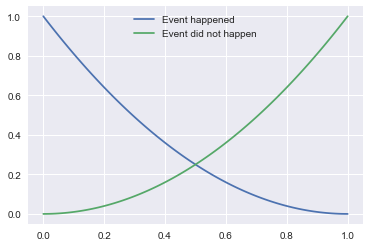

```python
scores_given_happened = np.square(xs - 1)
scores_given_not_happened = np.square(xs)

plt.plot(xs, scores_given_happened, label="Event happened")
plt.plot(xs, scores_given_not_happened, label="Event did not happen")
plt.legend()
plt.show()
```

The lower the Brier score, the better the forecast. However, something seems off: if I make a single forecast with 100% confidence, and it turns out I was right, I will have a perfect score of 0! The solution to this problem is that we are usually interested in what happens over many predictions, rather than a single prediction. The Brier score is a good indication of a forecaster's ability only when many forecasts are considered.

Over many forecasts, the Brier score can be calculated as the mean of the definition above:

$$ \frac{1}{N}\sum_{i=1}^N (f_i - o_i)^2 $$

where $N$ is the total number of event, $f_i$ is the estimated probability for the $i$th event and $o_i$ takes value 1 if the $i$th event happened, and 0 otherwise.

The expected value of the Brier score, if the actual probability of the event if $p$, is:

$$ p - 2pf + f^2 $$

as reporter [in this paper](https://rmets.onlinelibrary.wiley.com/doi/pdf/10.1002/met.21). The only way to minimize the expected BS is by making $f$ equal to $p$, which makes the Brier score a *proper* score. This means that if a forecaster is evaluated with the Brier score, she should try to make their guess close to the true value of the probability (this makes assumptions about the utility for the forecaster of different scores. This is discussed in detail in the paper above and I won't go into it).

We can now think about how the forecasters above would score in terms of the Brier score, by running a simple simulation. The simulation goes like this:

- A true event probability is sampled uniformly from the $[0, 1]$ interval.
- The forecaster is asked about an event with probability $p$, and estimates a probability $f$
- The event either happens or doesn't happen with probability $p$
- The Brier score is calculated
- The cycle is repeated $N$ times. This whole loop is then repeated many times, to find the *distribution of Brier scores* that that forecaster would get, if asked to make $N$ forecasts many times over.

First consider a totally unbiased and completely consistent forecaster (i.e. 0 variance in the estimates of the probabilities, given the true probability):

```python
def plot_forecaster(ax, fore_func=lambda x: x, event_func=np.random.uniform, max_asked=150):

    sns.set_palette("Blues", n_colors=9)
    for N in np.linspace(10, max_asked, 10).astype(int):
        n_trials = 10000
        p = event_func(size=(n_trials, N))
        f = fore_func(p)
        o = np.random.binomial(n=1,p=p)
        score = np.sum(np.square(f - o), axis=1)/N

        sns.distplot(score, label=f"N={N}", hist=False, ax=ax)

    ax1.set_xlabel("Brier scores")
    ax1.set_ylabel("Probability (density)")
    ax1.legend(title="Number of questions")
```

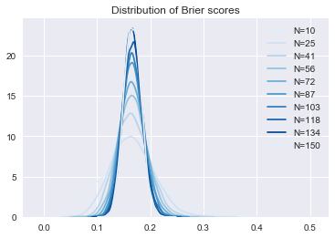

```python
fig, ax = plt.subplots()
plot_forecaster(ax)
ax.set_title("Distribution of Brier scores")
plt.show()
```

The crucial point of this plot is that the more forecasts we ask someone to produce, the lower the variance of the scores calculated for that forecaster. So in order for our Brier score to be a reliable indication of a forecaster's ability, we need to make sure that we are asking the forecaster enough questions that, if we were to evaluate the forecaster again by asking her the same number of questions on other events and calculating her Brier score again, the two scores would not be too different.

I assumed in the plot above that the forecaster is perfect, i.e. always produces exactly the right information. Let's see what happens when the forecaster is an overconfident forecaster like the one from the plot above:

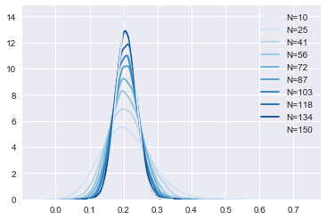

```python
fig, ax = plt.subplots()
plot_forecaster(ax, lambda p: logistic_sigmoid(p, 1, 0.5, 20))
ax1.set_title("Distribution of Brier scores\nfor overconfident forecasters")
plt.show()
```

The plot above assumes that the true probabilities of the events are sampled *uniformly* from the unit interval, i.e. all probabilities are equally likely. However, maybe you work in a field where you have to deal with extreme probabilities, which means probabilities near to 0 and 1. The probability of different probabilities is not uniform anymore then, but rather looks like this:

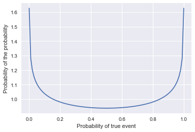

```python
fig, ax = plt.subplots()
xs = np.linspace(1e-3, 1-1e-3, 100)
ys = stats.beta.pdf(xs, 0.9, 0.9)
sns.lineplot(xs, ys, ax=ax)
ax.set_xlabel("Probability of true event")
ax.set_ylabel("Probability of the probability")
plt.show()
```

A question that arises is then: is the Brier score sensitive to the extremeness of the probabilities of the true events, given a perfect forecaster? Turns out it is!

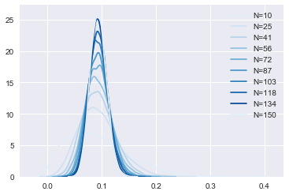

```python
fig, ax = plt.subplots()
plot_forecaster(ax, event_func=lambda size: stats.beta.rvs(0.3, 0.3, size=size))
ax1.set_title("Distribution of Brier scores\nfor overconfident forecasters")
plt.show()
```

This makes sense: imagine the extreme case where all the true probabilities are 0 or 1. Then, a perfect forecaster will always get not only the probability right, but also the actual event, and therefore will get a Brier score of 0. So in sum, the more extreme the events are, the lower on average are the Brier scores of accurate forecasters. Therefore, we must be careful when comparing Brier scores in different fields, especially if we have reasons to think that the underlying distribution of real probabilities is more extreme in one field than the other (this problem was discussed [here](https://ro-che.info/articles/2018-08-09-cheat-brier-score)).

We have seen three problems with Brier scores:

1. They only give us a measure of how good a forecaster is on average, but not in which ways she tends to fail as a forecaster. This is particularly useful in the prospect of improving the ability of specific forecasters.
2. They can lead us to make overconfindent estimates of a forecaster's abilities if not enough questions are asked.
3. They are sensitive to the distribution of the true probabilities, so forecasters in a field with extreme probabilities might appear more skillful than in a field with non-extreme probabilities, despite equal levels of skill. In the next section, I move to a different way of estimating a forecaster's ability, which I argues fares better on all these three problems.